# Manuscript_Tables_LongCovid

2023-08-23

## Main results

### Table 1: Baseline characteristics of individuals with COVID-19 and tested negative (earliest record)

|  | SIDIAP COVID-19 infection | SIDIAP First SARS-CoV-2 negative test | CPRD COVID-19 infection | CPRD First SARS-CoV-2 negative test |
| --- | --- | --- | --- | --- |
| N | 628,398 | 1,580,831 | 628,398 | 1,580,831 |
| Days of follow-up (median [iqr]) | 364 [314.00, 365.00] | 365 [333.00, 365.00] | 364 [314.00, 365.00] | 365 [333.00, 365.00] |
| Age (median [iqr]) | 42 [30.00, 55.00] | 41 [30.00, 55.00] | 42 [30.00, 55.00] | 41 [30.00, 55.00] |
| Age, categories (%) |  |  |  |  |
| <=34 | 218,004 (34.7) | 554,691 (35.1) | 218,004 (34.7) | 554,691 (35.1) |
| 35-49 | 182,989 (29.1) | 478,850 (30.3) | 182,989 (29.1) | 478,850 (30.3) |
| 50-64 | 153,942 (24.5) | 378,696 (24.0) | 153,942 (24.5) | 378,696 (24.0) |
| 65-79 | 52,079 (8.3) | 132,995 (8.4) | 52,079 (8.3) | 132,995 (8.4) |
| >=80 | 21,384 (3.4) | 35,599 (2.3) | 21,384 (3.4) | 35,599 (2.3) |
| Sex, female = male (%) | 282,580 (45.0) | 691,997 (43.8) | 282,580 (45.0) | 691,997 (43.8) |
| Trimester (%) |  |  |  |  |
| Sep-dec 2020 | 275,935 (43.9) | 950,689 (60.1) | 275,935 (43.9) | 950,689 (60.1) |
| Jan-apr 2021 | 256,584 (40.8) | 604,750 (38.3) | 256,584 (40.8) | 604,750 (38.3) |
| May-aug 2021 | 85,270 (13.6) | 25,245 (1.6) | 85,270 (13.6) | 25,245 (1.6) |
| Sep-dec 2021 | 10,609 (1.7) | 147 (0.0) | 10,609 (1.7) | 147 (0.0) |
| Wave (%) |  |  |  |  |
| Alpha | 337,265 (53.7) | 808,095 (51.1) | 337,265 (53.7) | 808,095 (51.1) |
| Delta | 92,010 (14.6) | 6,365 (0.4) | 92,010 (14.6) | 6,365 (0.4) |
| Wild | 199,123 (31.7) | 766,371 (48.5) | 199,123 (31.7) | 766,371 (48.5) |
| Vaccination status (%) |  |  |  |  |
| Non vaccinated | 93,376 (14.9) | 175,057 (11.1) | 93,376 (14.9) | 175,057 (11.1) |
| First dose vaccination | 86,108 (13.7) | 117,229 (7.4) | 86,108 (13.7) | 117,229 (7.4) |
| Two doses vaccination | 188,458 (30.0) | 500,891 (31.7) | 188,458 (30.0) | 500,891 (31.7) |
| Booster doses | 260,456 (41.4) | 787,654 (49.8) | 260,456 (41.4) | 787,654 (49.8) |
| PCR test (%) | 374,692 (59.6) | 1,580,831 (100.0) | 374,692 (59.6) | 1,580,831 (100.0) |
| **Comorbidities** |  |  |  |  |
| Asthma (%) | 107,520 (17.1) | 268,056 (17.0) | 107,520 (17.1) | 268,056 (17.0) |
| Autoimmune disease (%) | 17,517 (2.8) | 42,814 (2.7) | 17,517 (2.8) | 42,814 (2.7) |
| COPD (%) | 13,128 (2.1) | 28,089 (1.8) | 13,128 (2.1) | 28,089 (1.8) |
| Dementia (%) | 7,913 (1.3) | 14,466 (0.9) | 7,913 (1.3) | 14,466 (0.9) |
| Diabetes (%) | 51,397 (8.2) | 102,289 (6.5) | 51,397 (8.2) | 102,289 (6.5) |
| Heart disease (%) | 48,843 (7.8) | 105,120 (6.6) | 48,843 (7.8) | 105,120 (6.6) |
| Cancer (%) | 29,404 (4.7) | 72,807 (4.6) | 29,404 (4.7) | 72,807 (4.6) |
| Hypertension (%) | 93,392 (14.9) | 205,158 (13.0) | 93,392 (14.9) | 205,158 (13.0) |
| Renal impairment (%) | 28,778 (4.6) | 54,793 (3.5) | 28,778 (4.6) | 54,793 (3.5) |

### Figure 1: Incidence rates of COVID-19 and long-COVID-19

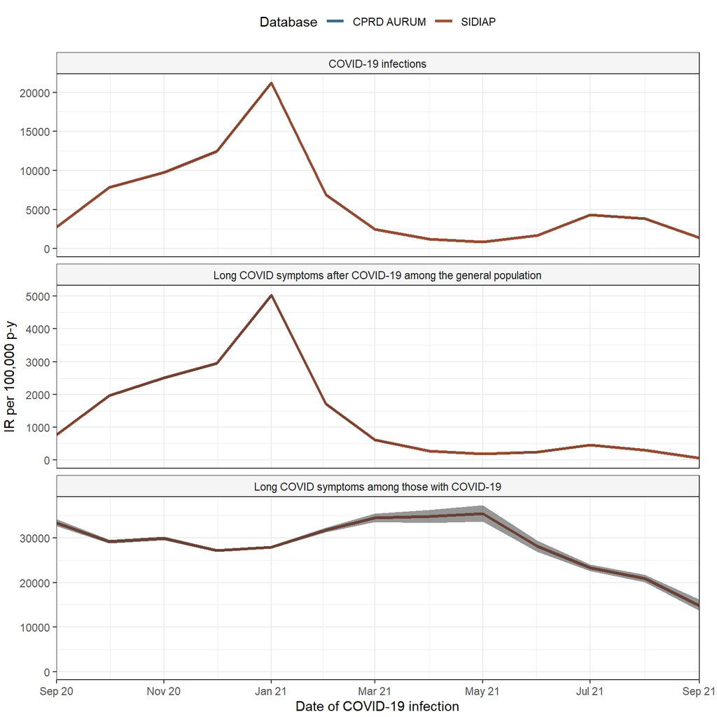

### Figure 2A: RR of long COVID symptoms: COVID-19 infection vs first SARS-CoV-2 negative test - 90 days, overall

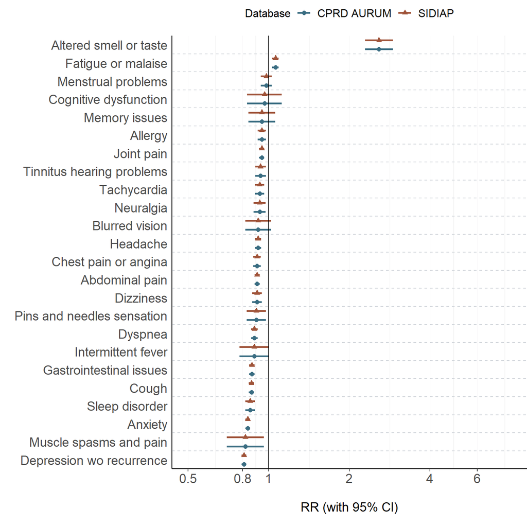

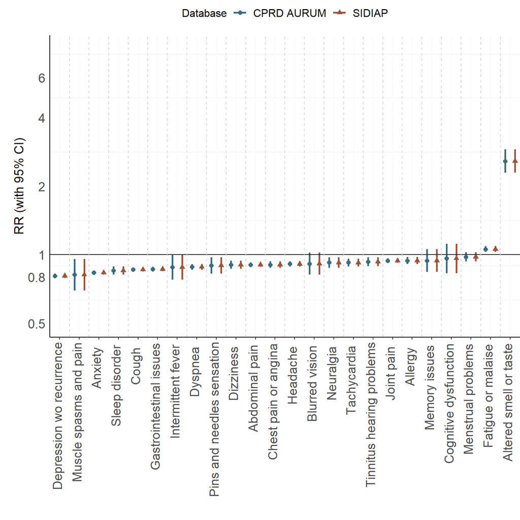

### Figure 2B: RR of long COVID symptoms: COVID-19 infection vs first SARS-CoV-2 negative test - 90 days, by waves

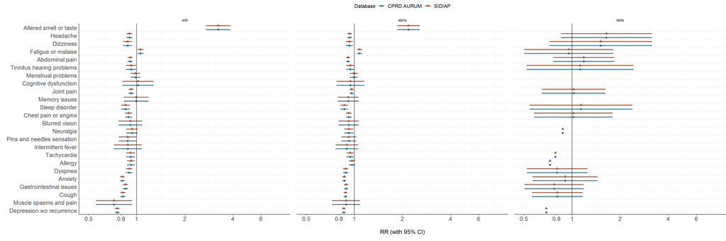

[figure not shown]

### Figure 3: RR of long-COVID symptoms: first infection vs re-infection - 90 days

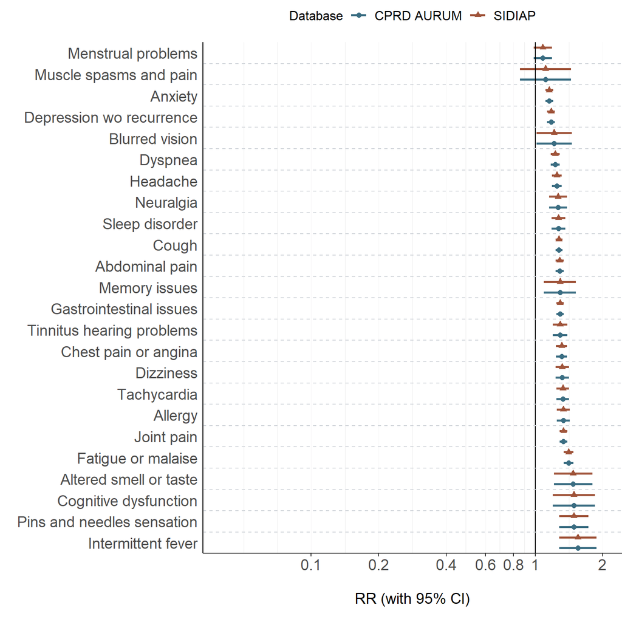

## Supplementary

### Baseline characteristics and symptoms distribution

#### 1. Table: Baseline characteristics of first infections, re-infections and all negative SARS-CoV-2 tests records

|  | SIDIAP First infection | SIDIAP Re-infections | SIDIAP SARS-CoV-2 negative tests, all records | CPRD First infection | CPRD Re-infections | CPRD SARS-CoV-2 negative tests, all records |
| --- | --- | --- | --- | --- | --- | --- |
| N | 465,059 | 163,339 | 5,046,826 | 465,059 | 163,339 | 5,046,826 |
| Days of follow-up (median [iqr]) | 365 [308.00, 365.00] | 360 [321.00, 365.00] | 352 [294.00, 365.00] | 365 [308.00, 365.00] | 360 [321.00, 365.00] | 352 [294.00, 365.00] |
| Age (median [iqr]) | 41 [29.00, 54.00] | 46 [33.00, 58.00] | 45 [32.00, 57.00] | 41 [29.00, 54.00] | 46 [33.00, 58.00] | 45 [32.00, 57.00] |
| Age, categories (%) |  |  |  |  |  |  |
| <=34 | 172,772 (37.2) | 45,232 (27.7) | 1,472,452 (29.2) | 172,772 (37.2) | 45,232 (27.7) | 1,472,452 (29.2) |
| 35-49 | 135,456 (29.1) | 47,533 (29.1) | 1,476,768 (29.3) | 135,456 (29.1) | 47,533 (29.1) | 1,476,768 (29.3) |
| 50-64 | 107,535 (23.1) | 46,407 (28.4) | 1,460,608 (28.9) | 107,535 (23.1) | 46,407 (28.4) | 1,460,608 (28.9) |
| 65-79 | 35,276 (7.6) | 16,803 (10.3) | 382,975 (7.6) | 35,276 (7.6) | 16,803 (10.3) | 382,975 (7.6) |
| >=80 | 14,020 (3.0) | 7,364 (4.5) | 254,023 (5.0) | 14,020 (3.0) | 7,364 (4.5) | 254,023 (5.0) |
| Sex, female = male (%) | 212,152 (45.6) | 70,428 (43.1) | 1,556,604 (30.8) | 212,152 (45.6) | 70,428 (43.1) | 1,556,604 (30.8) |
| Trimester (%) |  |  |  |  |  |  |
| Sep-dec 2020 | 208,770 (44.9) | 67,165 (41.1) | 2,170,205 (43.0) | 208,770 (44.9) | 67,165 (41.1) | 2,170,205 (43.0) |
| Jan-apr 2021 | 178,679 (38.4) | 77,905 (47.7) | 2,648,826 (52.5) | 178,679 (38.4) | 77,905 (47.7) | 2,648,826 (52.5) |
| May-aug 2021 | 69,268 (14.9) | 16,002 (9.8) | 227,553 (4.5) | 69,268 (14.9) | 16,002 (9.8) | 227,553 (4.5) |
| Sep-dec 2021 | 8,342 (1.8) | 2,267 (1.4) | 242 (0.0) | 8,342 (1.8) | 2,267 (1.4) | 242 (0.0) |
| Wave (%) |  |  |  |  |  |  |
| Alpha | 242,947 (52.2) | 94,318 (57.7) | 3,284,282 (65.1) | 242,947 (52.2) | 94,318 (57.7) | 3,284,282 (65.1) |
| Delta | 75,068 (16.1) | 16,942 (10.4) | 35,812 (0.7) | 75,068 (16.1) | 16,942 (10.4) | 35,812 (0.7) |
| Wild | 147,044 (31.6) | 52,079 (31.9) | 1,726,732 (34.2) | 147,044 (31.6) | 52,079 (31.9) | 1,726,732 (34.2) |
| Vaccination status (%) |  |  |  |  |  |  |
| Non vaccinated | 73,091 (15.7) | 20,285 (12.4) | 443,912 (8.8) | 73,091 (15.7) | 20,285 (12.4) | 443,912 (8.8) |
| First dose vaccination | 67,202 (14.5) | 18,906 (11.6) | 839,158 (16.6) | 67,202 (14.5) | 18,906 (11.6) | 839,158 (16.6) |
| Two doses vaccination | 138,493 (29.8) | 49,965 (30.6) | 1,857,334 (36.8) | 138,493 (29.8) | 49,965 (30.6) | 1,857,334 (36.8) |
| Booster doses | 186,273 (40.1) | 74,183 (45.4) | 1,906,422 (37.8) | 186,273 (40.1) | 74,183 (45.4) | 1,906,422 (37.8) |
| PCR test (%) | 334,360 (71.9) | 40,332 (24.7) | 5,046,826 (100.0) | 334,360 (71.9) | 40,332 (24.7) | 5,046,826 (100.0) |
| **Comorbidities** |  |  |  |  |  |  |
| Asthma (%) | 76,686 (16.5) | 30,834 (18.9) | 821,515 (16.3) | 76,686 (16.5) | 30,834 (18.9) | 821,515 (16.3) |
| Autoimmune disease (%) | 12,063 (2.6) | 5,454 (3.3) | 143,974 (2.9) | 12,063 (2.6) | 5,454 (3.3) | 143,974 (2.9) |
| COPD (%) | 8,575 (1.8) | 4,553 (2.8) | 95,111 (1.9) | 8,575 (1.8) | 4,553 (2.8) | 95,111 (1.9) |
| Dementia (%) | 4,941 (1.1) | 2,972 (1.8) | 171,887 (3.4) | 4,941 (1.1) | 2,972 (1.8) | 171,887 (3.4) |
| Diabetes (%) | 33,547 (7.2) | 17,850 (10.9) | 369,307 (7.3) | 33,547 (7.2) | 17,850 (10.9) | 369,307 (7.3) |
| Heart disease (%) | 32,645 (7.0) | 16,198 (9.9) | 372,430 (7.4) | 32,645 (7.0) | 16,198 (9.9) | 372,430 (7.4) |
| Cancer (%) | 20,163 (4.3) | 9,241 (5.7) | 253,739 (5.0) | 20,163 (4.3) | 9,241 (5.7) | 253,739 (5.0) |
| Hypertension (%) | 62,594 (13.5) | 30,798 (18.9) | 785,263 (15.6) | 62,594 (13.5) | 30,798 (18.9) | 785,263 (15.6) |
| Renal impairment (%) | 18,640 (4.0) | 10,138 (6.2) | 233,560 (4.6) | 18,640 (4.0) | 10,138 (6.2) | 233,560 (4.6) |

#### 2. Table: Symptoms distribution across cohorts (unmatched) - 90 days

|  | SIDIAP COVID-19 infection | SIDIAP First infection | SIDIAP Re-infections | SIDIAP SARS-CoV-2 negative tests | SIDIAP First SARS-CoV-2 negative test | CPRD COVID-19 infection | CPRD First infection | CPRD Re-infections | CPRD SARS-CoV-2 negative tests | CPRD First SARS-CoV-2 negative test |
| --- | --- | --- | --- | --- | --- | --- | --- | --- | --- | --- |
| N | 628,398 | 465,059 | 163,339 | 5,046,826 | 1,580,831 | 628,398 | 465,059 | 163,339 | 5,046,826 | 1,580,831 |
| Long Covid symptoms (%) | 141,819 (22.6) | 95,900 (20.6) | 45,919 (28.1) | 1,196,741 (23.7) | 367,772 (23.3) | 141,819 (22.6) | 95,900 (20.6) | 45,919 (28.1) | 1,196,741 (23.7) | 367,772 (23.3) |
| **Symptoms** |  |  |  |  |  |  |  |  |  |  |
| Abdominal pain (%) | 18,052 (2.9) | 12,124 (2.6) | 5,928 (3.6) | 152,160 (3.0) | 48,029 (3.0) | 18,052 (2.9) | 12,124 (2.6) | 5,928 (3.6) | 152,160 (3.0) | 48,029 (3.0) |
| Allergy (%) | 6,680 (1.1) | 4,490 (1.0) | 2,190 (1.3) | 50,855 (1.0) | 17,389 (1.1) | 6,680 (1.1) | 4,490 (1.0) | 2,190 (1.3) | 50,855 (1.0) | 17,389 (1.1) |
| Altered smell or taste (%) | 837 (0.1) | 570 (0.1) | 267 (0.2) | 2,331 (0.0) | 867 (0.1) | 837 (0.1) | 570 (0.1) | 267 (0.2) | 2,331 (0.0) | 867 (0.1) |
| Anxiety (%) | 19,195 (3.1) | 13,426 (2.9) | 5,769 (3.5) | 175,335 (3.5) | 55,869 (3.5) | 19,195 (3.1) | 13,426 (2.9) | 5,769 (3.5) | 175,335 (3.5) | 55,869 (3.5) |
| Blurred vision (%) | 822 (0.1) | 543 (0.1) | 279 (0.2) | 6,608 (0.1) | 2,090 (0.1) | 822 (0.1) | 543 (0.1) | 279 (0.2) | 6,608 (0.1) | 2,090 (0.1) |
| Chest pain or angina (%) | 9,263 (1.5) | 6,040 (1.3) | 3,223 (2.0) | 69,562 (1.4) | 23,017 (1.5) | 9,263 (1.5) | 6,040 (1.3) | 3,223 (2.0) | 69,562 (1.4) | 23,017 (1.5) |
| Cognitive dysfunction (%) | 537 (0.1) | 324 (0.1) | 213 (0.1) | 5,029 (0.1) | 1,115 (0.1) | 537 (0.1) | 324 (0.1) | 213 (0.1) | 5,029 (0.1) | 1,115 (0.1) |
| Cough (%) | 21,166 (3.4) | 13,947 (3.0) | 7,219 (4.4) | 185,700 (3.7) | 52,248 (3.3) | 21,166 (3.4) | 13,947 (3.0) | 7,219 (4.4) | 185,700 (3.7) | 52,248 (3.3) |
| Depression wo recurrence (%) | 19,145 (3.0) | 13,171 (2.8) | 5,974 (3.7) | 185,170 (3.7) | 56,145 (3.6) | 19,145 (3.0) | 13,171 (2.8) | 5,974 (3.7) | 185,170 (3.7) | 56,145 (3.6) |
| Dizziness (%) | 5,803 (0.9) | 3,769 (0.8) | 2,034 (1.2) | 46,489 (0.9) | 14,815 (0.9) | 5,803 (0.9) | 3,769 (0.8) | 2,034 (1.2) | 46,489 (0.9) | 14,815 (0.9) |
| Dyspnea (%) | 13,148 (2.1) | 8,485 (1.8) | 4,663 (2.9) | 91,802 (1.8) | 29,360 (1.9) | 13,148 (2.1) | 8,485 (1.8) | 4,663 (2.9) | 91,802 (1.8) | 29,360 (1.9) |
| Fatigue or malaise (%) | 11,597 (1.8) | 7,496 (1.6) | 4,101 (2.5) | 85,464 (1.7) | 26,031 (1.6) | 11,597 (1.8) | 7,496 (1.6) | 4,101 (2.5) | 85,464 (1.7) | 26,031 (1.6) |
| Gastrointestinal issues (%) | 17,372 (2.8) | 11,408 (2.5) | 5,964 (3.7) | 144,986 (2.9) | 45,346 (2.9) | 17,372 (2.8) | 11,408 (2.5) | 5,964 (3.7) | 144,986 (2.9) | 45,346 (2.9) |
| Headache (%) | 12,416 (2.0) | 8,346 (1.8) | 4,070 (2.5) | 103,725 (2.1) | 33,664 (2.1) | 12,416 (2.0) | 8,346 (1.8) | 4,070 (2.5) | 103,725 (2.1) | 33,664 (2.1) |
| Intermittent fever (%) | 688 (0.1) | 420 (0.1) | 268 (0.2) | 5,935 (0.1) | 1,580 (0.1) | 688 (0.1) | 420 (0.1) | 268 (0.2) | 5,935 (0.1) | 1,580 (0.1) |
| Joint pain (%) | 18,340 (2.9) | 12,018 (2.6) | 6,322 (3.9) | 153,619 (3.0) | 46,493 (2.9) | 18,340 (2.9) | 12,018 (2.6) | 6,322 (3.9) | 153,619 (3.0) | 46,493 (2.9) |
| Memory issues (%) | 905 (0.1) | 567 (0.1) | 338 (0.2) | 5,999 (0.1) | 1,859 (0.1) | 905 (0.1) | 567 (0.1) | 338 (0.2) | 5,999 (0.1) | 1,859 (0.1) |
| Menstrual problems (%) | 3,882 (0.6) | 2,772 (0.6) | 1,110 (0.7) | 35,392 (0.7) | 10,759 (0.7) | 3,882 (0.6) | 2,772 (0.6) | 1,110 (0.7) | 35,392 (0.7) | 10,759 (0.7) |
| Muscle spasms and pain (%) | 386 (0.1) | 261 (0.1) | 125 (0.1) | 3,260 (0.1) | 1,094 (0.1) | 386 (0.1) | 261 (0.1) | 125 (0.1) | 3,260 (0.1) | 1,094 (0.1) |
| Neuralgia (%) | 3,439 (0.5) | 2,286 (0.5) | 1,153 (0.7) | 30,041 (0.6) | 8,972 (0.6) | 3,439 (0.5) | 2,286 (0.5) | 1,153 (0.7) | 30,041 (0.6) | 8,972 (0.6) |
| Pins and needles sensation (%) | 1,357 (0.2) | 869 (0.2) | 488 (0.3) | 10,827 (0.2) | 3,512 (0.2) | 1,357 (0.2) | 869 (0.2) | 488 (0.3) | 10,827 (0.2) | 3,512 (0.2) |
| Postexertional fatigue = 0 (%) | 628,398 (100.0) | 465,059 (100.0) | 163,339 (100.0) | 5,046,826 (100.0) | 1,580,831 (100.0) | 628,398 (100.0) | 465,059 (100.0) | 163,339 (100.0) | 5,046,826 (100.0) | 1,580,831 (100.0) |
| Sleep disorder (%) | 5,588 (0.9) | 3,644 (0.8) | 1,944 (1.2) | 46,204 (0.9) | 14,641 (0.9) | 5,588 (0.9) | 3,644 (0.8) | 1,944 (1.2) | 46,204 (0.9) | 14,641 (0.9) |
| Tachycardia (%) | 6,453 (1.0) | 4,161 (0.9) | 2,292 (1.4) | 48,714 (1.0) | 15,380 (1.0) | 6,453 (1.0) | 4,161 (0.9) | 2,292 (1.4) | 48,714 (1.0) | 15,380 (1.0) |
| Tinnitus hearing problems (%) | 4,737 (0.8) | 3,085 (0.7) | 1,652 (1.0) | 38,902 (0.8) | 11,871 (0.8) | 4,737 (0.8) | 3,085 (0.7) | 1,652 (1.0) | 38,902 (0.8) | 11,871 (0.8) |
| Number of symptoms (%) |  |  |  |  |  |  |  |  |  |  |
| 0 | 486,579 (77.4) | 369,159 (79.4) | 117,420 (71.9) | 3,850,085 (76.3) | 1,213,059 (76.7) | 486,579 (77.4) | 369,159 (79.4) | 117,420 (71.9) | 3,850,085 (76.3) | 1,213,059 (76.7) |
| 1 | 98,575 (15.7) | 67,692 (14.6) | 30,883 (18.9) | 836,732 (16.6) | 254,921 (16.1) | 98,575 (15.7) | 67,692 (14.6) | 30,883 (18.9) | 836,732 (16.6) | 254,921 (16.1) |
| 2 | 31,318 (5.0) | 20,944 (4.5) | 10,374 (6.4) | 265,497 (5.3) | 82,330 (5.2) | 31,318 (5.0) | 20,944 (4.5) | 10,374 (6.4) | 265,497 (5.3) | 82,330 (5.2) |
| 3 | 8,552 (1.4) | 5,226 (1.1) | 3,326 (2.0) | 70,146 (1.4) | 22,402 (1.4) | 8,552 (1.4) | 5,226 (1.1) | 3,326 (2.0) | 70,146 (1.4) | 22,402 (1.4) |
| 4 | 2,380 (0.4) | 1,459 (0.3) | 921 (0.6) | 18,187 (0.4) | 5,978 (0.4) | 2,380 (0.4) | 1,459 (0.3) | 921 (0.6) | 18,187 (0.4) | 5,978 (0.4) |
| 5 | 690 (0.1) | 422 (0.1) | 268 (0.2) | 4,599 (0.1) | 1,610 (0.1) | 690 (0.1) | 422 (0.1) | 268 (0.2) | 4,599 (0.1) | 1,610 (0.1) |
| 6 | 205 (0.0) | 103 (0.0) | 102 (0.1) | 1,082 (0.0) | 378 (0.0) | 205 (0.0) | 103 (0.0) | 102 (0.1) | 1,082 (0.0) | 378 (0.0) |
| 7 | 63 (0.0) | 37 (0.0) | 26 (0.0) | 337 (0.0) | 113 (0.0) | 63 (0.0) | 37 (0.0) | 26 (0.0) | 337 (0.0) | 113 (0.0) |
| 8 | 28 (0.0) | 14 (0.0) | 14 (0.0) | 105 (0.0) | 27 (0.0) | 28 (0.0) | 14 (0.0) | 14 (0.0) | 105 (0.0) | 27 (0.0) |
| 9 | 5 (0.0) | <5 | <5 | 52 (0.0) | 10 (0.0) | 5 (0.0) | <5 | <5 | 52 (0.0) | 10 (0.0) |
| 10 | <5 | <5 | <5 | <5 | <5 | <5 | <5 | <5 | <5 | <5 |
| 11 | <5 | <5 | <5 | <5 | <5 | <5 | <5 | <5 | <5 | <5 |
| Days elapsed since index date and record of symptom (median [iqr]) | 183 [127.00, 259.00] | 184 [128.00, 262.00] | 179 [125.00, 253.00] | 187 [132.00, 253.00] | 192 [134.00, 264.00] | 183 [127.00, 259.00] | 184 [128.00, 262.00] | 179 [125.00, 253.00] | 187 [132.00, 253.00] | 192 [134.00, 264.00] |

#### 3. Table: Symptoms distribution across cohorts (unmatched) - 28 days

|  | SIDIAP COVID-19 infection | SIDIAP First infection | SIDIAP Re-infections | SIDIAP SARS-CoV-2 negative tests | SIDIAP First SARS-CoV-2 negative test | CPRD COVID-19 infection | CPRD First infection | CPRD Re-infections | CPRD SARS-CoV-2 negative tests | CPRD First SARS-CoV-2 negative test |
| --- | --- | --- | --- | --- | --- | --- | --- | --- | --- | --- |
| N | 628,398 | 465,059 | 163,339 | 5,046,826 | 1,580,831 | 628,398 | 465,059 | 163,339 | 5,046,826 | 1,580,831 |
| Long Covid symptoms (%) | 169,137 (26.9) | 114,827 (24.7) | 54,310 (33.2) | 1,394,734 (27.6) | 424,303 (26.8) | 169,137 (26.9) | 114,827 (24.7) | 54,310 (33.2) | 1,394,734 (27.6) | 424,303 (26.8) |
| **Symptoms** |  |  |  |  |  |  |  |  |  |  |
| Abdominal pain (%) | 22,424 (3.6) | 15,124 (3.3) | 7,300 (4.5) | 187,748 (3.7) | 58,501 (3.7) | 22,424 (3.6) | 15,124 (3.3) | 7,300 (4.5) | 187,748 (3.7) | 58,501 (3.7) |
| Allergy (%) | 8,077 (1.3) | 5,407 (1.2) | 2,670 (1.6) | 63,567 (1.3) | 20,751 (1.3) | 8,077 (1.3) | 5,407 (1.2) | 2,670 (1.6) | 63,567 (1.3) | 20,751 (1.3) |
| Altered smell or taste (%) | 1,096 (0.2) | 736 (0.2) | 360 (0.2) | 2,834 (0.1) | 1,056 (0.1) | 1,096 (0.2) | 736 (0.2) | 360 (0.2) | 2,834 (0.1) | 1,056 (0.1) |
| Anxiety (%) | 23,334 (3.7) | 16,282 (3.5) | 7,052 (4.3) | 209,022 (4.1) | 65,818 (4.2) | 23,334 (3.7) | 16,282 (3.5) | 7,052 (4.3) | 209,022 (4.1) | 65,818 (4.2) |
| Blurred vision (%) | 1,051 (0.2) | 701 (0.2) | 350 (0.2) | 8,413 (0.2) | 2,575 (0.2) | 1,051 (0.2) | 701 (0.2) | 350 (0.2) | 8,413 (0.2) | 2,575 (0.2) |
| Chest pain or angina (%) | 12,094 (1.9) | 7,846 (1.7) | 4,248 (2.6) | 86,282 (1.7) | 28,259 (1.8) | 12,094 (1.9) | 7,846 (1.7) | 4,248 (2.6) | 86,282 (1.7) | 28,259 (1.8) |
| Cognitive dysfunction (%) | 684 (0.1) | 411 (0.1) | 273 (0.2) | 6,156 (0.1) | 1,327 (0.1) | 684 (0.1) | 411 (0.1) | 273 (0.2) | 6,156 (0.1) | 1,327 (0.1) |
| Cough (%) | 25,615 (4.1) | 17,003 (3.7) | 8,612 (5.3) | 213,536 (4.2) | 60,847 (3.8) | 25,615 (4.1) | 17,003 (3.7) | 8,612 (5.3) | 213,536 (4.2) | 60,847 (3.8) |
| Depression wo recurrence (%) | 22,787 (3.6) | 15,727 (3.4) | 7,060 (4.3) | 218,307 (4.3) | 65,599 (4.1) | 22,787 (3.6) | 15,727 (3.4) | 7,060 (4.3) | 218,307 (4.3) | 65,599 (4.1) |
| Dizziness (%) | 7,254 (1.2) | 4,711 (1.0) | 2,543 (1.6) | 57,476 (1.1) | 17,990 (1.1) | 7,254 (1.2) | 4,711 (1.0) | 2,543 (1.6) | 57,476 (1.1) | 17,990 (1.1) |
| Dyspnea (%) | 17,434 (2.8) | 11,190 (2.4) | 6,244 (3.8) | 111,892 (2.2) | 35,607 (2.3) | 17,434 (2.8) | 11,190 (2.4) | 6,244 (3.8) | 111,892 (2.2) | 35,607 (2.3) |
| Fatigue or malaise (%) | 14,865 (2.4) | 9,553 (2.1) | 5,312 (3.3) | 105,229 (2.1) | 31,438 (2.0) | 14,865 (2.4) | 9,553 (2.1) | 5,312 (3.3) | 105,229 (2.1) | 31,438 (2.0) |
| Gastrointestinal issues (%) | 21,773 (3.5) | 14,343 (3.1) | 7,430 (4.5) | 178,195 (3.5) | 55,071 (3.5) | 21,773 (3.5) | 14,343 (3.1) | 7,430 (4.5) | 178,195 (3.5) | 55,071 (3.5) |
| Headache (%) | 15,389 (2.4) | 10,359 (2.2) | 5,030 (3.1) | 129,099 (2.6) | 41,021 (2.6) | 15,389 (2.4) | 10,359 (2.2) | 5,030 (3.1) | 129,099 (2.6) | 41,021 (2.6) |
| Intermittent fever (%) | 881 (0.1) | 538 (0.1) | 343 (0.2) | 7,494 (0.1) | 1,937 (0.1) | 881 (0.1) | 538 (0.1) | 343 (0.2) | 7,494 (0.1) | 1,937 (0.1) |
| Joint pain (%) | 22,117 (3.5) | 14,521 (3.1) | 7,596 (4.7) | 183,831 (3.6) | 54,819 (3.5) | 22,117 (3.5) | 14,521 (3.1) | 7,596 (4.7) | 183,831 (3.6) | 54,819 (3.5) |
| Memory issues (%) | 1,160 (0.2) | 727 (0.2) | 433 (0.3) | 7,217 (0.1) | 2,184 (0.1) | 1,160 (0.2) | 727 (0.2) | 433 (0.3) | 7,217 (0.1) | 2,184 (0.1) |
| Menstrual problems (%) | 4,932 (0.8) | 3,542 (0.8) | 1,390 (0.9) | 43,834 (0.9) | 13,132 (0.8) | 4,932 (0.8) | 3,542 (0.8) | 1,390 (0.9) | 43,834 (0.9) | 13,132 (0.8) |
| Muscle spasms and pain (%) | 484 (0.1) | 336 (0.1) | 148 (0.1) | 3,883 (0.1) | 1,289 (0.1) | 484 (0.1) | 336 (0.1) | 148 (0.1) | 3,883 (0.1) | 1,289 (0.1) |
| Neuralgia (%) | 4,166 (0.7) | 2,780 (0.6) | 1,386 (0.8) | 36,770 (0.7) | 10,681 (0.7) | 4,166 (0.7) | 2,780 (0.6) | 1,386 (0.8) | 36,770 (0.7) | 10,681 (0.7) |
| Pins and needles sensation (%) | 1,754 (0.3) | 1,122 (0.2) | 632 (0.4) | 13,422 (0.3) | 4,307 (0.3) | 1,754 (0.3) | 1,122 (0.2) | 632 (0.4) | 13,422 (0.3) | 4,307 (0.3) |
| Postexertional fatigue = 0 (%) | 628,398 (100.0) | 465,059 (100.0) | 163,339 (100.0) | 5,046,826 (100.0) | 1,580,831 (100.0) | 628,398 (100.0) | 465,059 (100.0) | 163,339 (100.0) | 5,046,826 (100.0) | 1,580,831 (100.0) |
| Sleep disorder (%) | 7,358 (1.2) | 4,788 (1.0) | 2,570 (1.6) | 58,005 (1.1) | 18,374 (1.2) | 7,358 (1.2) | 4,788 (1.0) | 2,570 (1.6) | 58,005 (1.1) | 18,374 (1.2) |
| Tachycardia (%) | 8,318 (1.3) | 5,346 (1.1) | 2,972 (1.8) | 59,274 (1.2) | 18,424 (1.2) | 8,318 (1.3) | 5,346 (1.1) | 2,972 (1.8) | 59,274 (1.2) | 18,424 (1.2) |
| Tinnitus hearing problems (%) | 5,876 (0.9) | 3,819 (0.8) | 2,057 (1.3) | 47,349 (0.9) | 14,300 (0.9) | 5,876 (0.9) | 3,819 (0.8) | 2,057 (1.3) | 47,349 (0.9) | 14,300 (0.9) |
| Number of symptoms (%) |  |  |  |  |  |  |  |  |  |  |
| 0 | 459,261 (73.1) | 350,232 (75.3) | 109,029 (66.8) | 3,652,092 (72.4) | 1,156,528 (73.2) | 459,261 (73.1) | 350,232 (75.3) | 109,029 (66.8) | 3,652,092 (72.4) | 1,156,528 (73.2) |
| 1 | 112,532 (17.9) | 77,932 (16.8) | 34,600 (21.2) | 935,732 (18.5) | 282,530 (17.9) | 112,532 (17.9) | 77,932 (16.8) | 34,600 (21.2) | 935,732 (18.5) | 282,530 (17.9) |
| 2 | 39,259 (6.2) | 26,287 (5.7) | 12,972 (7.9) | 325,988 (6.5) | 99,583 (6.3) | 39,259 (6.2) | 26,287 (5.7) | 12,972 (7.9) | 325,988 (6.5) | 99,583 (6.3) |
| 3 | 11,987 (1.9) | 7,417 (1.6) | 4,570 (2.8) | 95,197 (1.9) | 29,886 (1.9) | 11,987 (1.9) | 7,417 (1.6) | 4,570 (2.8) | 95,197 (1.9) | 29,886 (1.9) |
| 4 | 3,652 (0.6) | 2,198 (0.5) | 1,454 (0.9) | 27,510 (0.5) | 8,859 (0.6) | 3,652 (0.6) | 2,198 (0.5) | 1,454 (0.9) | 27,510 (0.5) | 8,859 (0.6) |
| 5 | 1,200 (0.2) | 719 (0.2) | 481 (0.3) | 7,550 (0.1) | 2,505 (0.2) | 1,200 (0.2) | 719 (0.2) | 481 (0.3) | 7,550 (0.1) | 2,505 (0.2) |
| 6 | 330 (0.1) | 185 (0.0) | 145 (0.1) | 1,899 (0.0) | 678 (0.0) | 330 (0.1) | 185 (0.0) | 145 (0.1) | 1,899 (0.0) | 678 (0.0) |
| 7 | 113 (0.0) | 61 (0.0) | 52 (0.0) | 598 (0.0) | 196 (0.0) | 113 (0.0) | 61 (0.0) | 52 (0.0) | 598 (0.0) | 196 (0.0) |
| 8 | 49 (0.0) | 23 (0.0) | 26 (0.0) | 186 (0.0) | 48 (0.0) | 49 (0.0) | 23 (0.0) | 26 (0.0) | 186 (0.0) | 48 (0.0) |
| 9 | 11 (0.0) | <5 | 7 (0.0) | 65 (0.0) | 14 (0.0) | 11 (0.0) | <5 | 7 (0.0) | 65 (0.0) | 14 (0.0) |
| 10 | <5 | <5 | <5 | 6 (0.0) | <5 | <5 | <5 | <5 | 6 (0.0) | <5 |
| 11 | <5 | <5 | <5 | <5 | <5 | <5 | <5 | <5 | <5 | <5 |
| Days elapsed since index date and record of symptom (median [iqr]) | 139 [75.00, 230.00] | 141 [76.00, 233.00] | 134 [71.00, 224.00] | 149 [81.00, 231.00] | 155 [83.00, 242.00] | 139 [75.00, 230.00] | 141 [76.00, 233.00] | 134 [71.00, 224.00] | 149 [81.00, 231.00] | 155 [83.00, 242.00] |

#### 4. Table: Baseline characteristics - COVID-19 infection vs first negative test matched 3:1

|  | SIDIAP COVID-19 infection | SIDIAP First SARS-CoV-2 negative test | SIDIAP SMD | CPRD COVID-19 infection | CPRD First SARS-CoV-2 negative test | CPRD SMD |
| --- | --- | --- | --- | --- | --- | --- |
| N | 367,781 | 993,684 |  | 367,781 | 993,684 |  |
| Days of follow-up (median [iqr]) | 365 [352.00, 365.00] | 365 [348.00, 365.00] | 0.076 | 365 [352.00, 365.00] | 365 [348.00, 365.00] | 0.076 |
| Age (median [iqr]) | 40 [29.00, 53.00] | 40 [29.00, 53.00] | 0.001 | 40 [29.00, 53.00] | 40 [29.00, 53.00] | 0.001 |
| Age, categories (%) |  |  | <0.001 |  |  | <0.001 |
| <=34 | 137,596 (37.4) | 371,761.8 (37.4) |  | 137,596 (37.4) | 371,761.8 (37.4) |  |
| 35-49 | 111,034 (30.2) | 299,995.7 (30.2) |  | 111,034 (30.2) | 299,995.7 (30.2) |  |
| 50-64 | 87,709 (23.8) | 236,975.3 (23.8) |  | 87,709 (23.8) | 236,975.3 (23.8) |  |
| 65-79 | 23,776 (6.5) | 64,238.9 (6.5) |  | 23,776 (6.5) | 64,238.9 (6.5) |  |
| >=80 | 7,666 (2.1) | 20,712.3 (2.1) |  | 7,666 (2.1) | 20,712.3 (2.1) |  |
| Sex, female = male (%) | 167,683 (45.6) | 453,052 (45.6) | <0.001 | 167,683 (45.6) | 453,052 (45.6) | <0.001 |
| Trimester (%) |  |  | <0.001 |  |  | <0.001 |
| Sep-dec 2020 | 192,388 (52.3) | 519,800.9 (52.3) |  | 192,388 (52.3) | 519,800.9 (52.3) |  |
| Jan-apr 2021 | 171,785 (46.7) | 464,156.5 (46.7) |  | 171,785 (46.7) | 464,156.5 (46.7) |  |
| May-aug 2021 | 3,467 (0.9) | 9,353.8 (0.9) |  | 3,467 (0.9) | 9,353.8 (0.9) |  |
| Sep-dec 2021 | 141 (0.0) | 372.9 (0.0) |  | 141 (0.0) | 372.9 (0.0) |  |
| Wave (%) |  |  | 0.001 |  |  | 0.001 |
| Alpha | 233,764 (63.6) | 631,213.8 (63.5) |  | 233,764 (63.6) | 631,213.8 (63.5) |  |
| Delta | 2,250 (0.6) | 6,062 (0.6) |  | 2,250 (0.6) | 6,062 (0.6) |  |
| Wild | 131,767 (35.8) | 356,408.2 (35.9) |  | 131,767 (35.8) | 356,408.2 (35.9) |  |
| Vaccination status (%) |  |  | 0.077 |  |  | 0.077 |
| Non vaccinated | 46,867 (12.7) | 112,266.7 (11.3) |  | 46,867 (12.7) | 112,266.7 (11.3) |  |
| First dose vaccination | 24,016 (6.5) | 64,372.6 (6.5) |  | 24,016 (6.5) | 64,372.6 (6.5) |  |
| Two doses vaccination | 121,634 (33.1) | 307,206.4 (30.9) |  | 121,634 (33.1) | 307,206.4 (30.9) |  |
| Booster doses | 175,264 (47.7) | 509,838.3 (51.3) |  | 175,264 (47.7) | 509,838.3 (51.3) |  |
| PCR test (%) | 367,781 (100.0) | 993,684 (100.0) | <0.001 | 367,781 (100.0) | 993,684 (100.0) | <0.001 |
| **Comorbidities** |  |  |  |  |  |  |
| Asthma (%) | 56,305 (15.3) | 170,319.7 (17.1) | 0.050 | 56,305 (15.3) | 170,319.7 (17.1) | 0.050 |
| Autoimmune disease (%) | 8,813 (2.4) | 25,473.8 (2.6) | 0.011 | 8,813 (2.4) | 25,473.8 (2.6) | 0.011 |
| COPD (%) | 4,246 (1.2) | 15,815.6 (1.6) | 0.038 | 4,246 (1.2) | 15,815.6 (1.6) | 0.038 |
| Dementia (%) | 3,685 (1.0) | 7,656.1 (0.8) | 0.025 | 3,685 (1.0) | 7,656.1 (0.8) | 0.025 |
| Diabetes (%) | 24,463 (6.7) | 60,192 (6.1) | 0.024 | 24,463 (6.7) | 60,192 (6.1) | 0.024 |
| Heart disease (%) | 21,698 (5.9) | 61,952.7 (6.2) | 0.014 | 21,698 (5.9) | 61,952.7 (6.2) | 0.014 |
| Cancer (%) | 13,680 (3.7) | 40,867.5 (4.1) | 0.020 | 13,680 (3.7) | 40,867.5 (4.1) | 0.020 |
| Hypertension (%) | 45,275 (12.3) | 119,140.2 (12.0) | 0.010 | 45,275 (12.3) | 119,140.2 (12.0) | 0.010 |
| Renal impairment (%) | 11,712 (3.2) | 31,038.2 (3.1) | 0.003 | 11,712 (3.2) | 31,038.2 (3.1) | 0.003 |

#### 5. Table: Baseline characteristics: first COVID-19 infection vs re-infections matched 1:3

|  | SIDIAP First infection | SIDIAP Re-infections | SIDIAP SMD | CPRD First infection | CPRD Re-infections | CPRD SMD |
| --- | --- | --- | --- | --- | --- | --- |
| N | 225,936 | 110,022 |  | 225,936 | 110,022 |  |
| Days of follow-up (median [iqr]) | 360 [288.00, 365.00] | 360 [291.00, 365.00] | 0.009 | 360 [288.00, 365.00] | 360 [291.00, 365.00] | 0.009 |
| Age (median [iqr]) | 45 [32.00, 59.00] | 45 [32.00, 59.00] | <0.001 | 45 [32.00, 59.00] | 45 [32.00, 59.00] | <0.001 |
| Age, categories (%) |  |  | <0.001 |  |  | <0.001 |
| <=34 | 68,237.5 (30.2) | 33,229 (30.2) |  | 68,237.5 (30.2) | 33,229 (30.2) |  |
| 35-49 | 61,512.1 (27.2) | 29,954 (27.2) |  | 61,512.1 (27.2) | 29,954 (27.2) |  |
| 50-64 | 57,113.4 (25.3) | 27,812 (25.3) |  | 57,113.4 (25.3) | 27,812 (25.3) |  |
| 65-79 | 26,110.9 (11.6) | 12,715 (11.6) |  | 26,110.9 (11.6) | 12,715 (11.6) |  |
| >=80 | 12,962 (5.7) | 6,312 (5.7) |  | 12,962 (5.7) | 6,312 (5.7) |  |
| Sex, female = male (%) | 96,282.9 (42.6) | 46,886 (42.6) | <0.001 | 96,282.9 (42.6) | 46,886 (42.6) | <0.001 |
| Trimester (%) |  |  | 0.004 |  |  | 0.004 |
| Sep-dec 2020 | 98,927.9 (43.8) | 48,174 (43.8) |  | 98,927.9 (43.8) | 48,174 (43.8) |  |
| Jan-apr 2021 | 89,827.5 (39.8) | 43,730 (39.7) |  | 89,827.5 (39.8) | 43,730 (39.7) |  |
| May-aug 2021 | 32,653.5 (14.5) | 15,860 (14.4) |  | 32,653.5 (14.5) | 15,860 (14.4) |  |
| Sep-dec 2021 | 4,527.1 (2.0) | 2,258 (2.1) |  | 4,527.1 (2.0) | 2,258 (2.1) |  |
| Wave (%) |  |  | 0.001 |  |  | 0.001 |
| Alpha | 113,235.6 (50.1) | 55,179 (50.2) |  | 113,235.6 (50.1) | 55,179 (50.2) |  |
| Delta | 34,698.9 (15.4) | 16,884 (15.3) |  | 34,698.9 (15.4) | 16,884 (15.3) |  |
| Wild | 78,001.5 (34.5) | 37,959 (34.5) |  | 78,001.5 (34.5) | 37,959 (34.5) |  |
| Vaccination status (%) |  |  | 0.070 |  |  | 0.070 |
| Non vaccinated | 34,913.5 (15.5) | 15,128 (13.7) |  | 34,913.5 (15.5) | 15,128 (13.7) |  |
| First dose vaccination | 35,706.2 (15.8) | 15,797 (14.4) |  | 35,706.2 (15.8) | 15,797 (14.4) |  |
| Two doses vaccination | 66,459.5 (29.4) | 33,455 (30.4) |  | 66,459.5 (29.4) | 33,455 (30.4) |  |
| Booster doses | 88,856.9 (39.3) | 45,642 (41.5) |  | 88,856.9 (39.3) | 45,642 (41.5) |  |
| PCR test (%) | 82,702.7 (36.6) | 40,273 (36.6) | <0.001 | 82,702.7 (36.6) | 40,273 (36.6) | <0.001 |
| **Comorbidities** |  |  |  |  |  |  |
| Asthma (%) | 41,923.3 (18.6) | 20,919 (19.0) | 0.012 | 41,923.3 (18.6) | 20,919 (19.0) | 0.012 |
| Autoimmune disease (%) | 7,436.6 (3.3) | 3,771 (3.4) | 0.008 | 7,436.6 (3.3) | 3,771 (3.4) | 0.008 |
| COPD (%) | 8,194.4 (3.6) | 3,423 (3.1) | 0.029 | 8,194.4 (3.6) | 3,423 (3.1) | 0.029 |
| Dementia (%) | 3,933.9 (1.7) | 2,392 (2.2) | 0.031 | 3,933.9 (1.7) | 2,392 (2.2) | 0.031 |
| Diabetes (%) | 22,897.5 (10.1) | 11,973 (10.9) | 0.024 | 22,897.5 (10.1) | 11,973 (10.9) | 0.024 |
| Heart disease (%) | 23,973.2 (10.6) | 11,771 (10.7) | 0.003 | 23,973.2 (10.6) | 11,771 (10.7) | 0.003 |
| Cancer (%) | 14,197.2 (6.3) | 6,789 (6.2) | 0.005 | 14,197.2 (6.3) | 6,789 (6.2) | 0.005 |
| Hypertension (%) | 42,227.6 (18.7) | 21,289 (19.3) | 0.017 | 42,227.6 (18.7) | 21,289 (19.3) | 0.017 |
| Renal impairment (%) | 15,121.7 (6.7) | 7,613 (6.9) | 0.009 | 15,121.7 (6.7) | 7,613 (6.9) | 0.009 |

### Incidence Rates

#### 1. Table: Incidence Rates of COVID-19 & long COVID symptoms

| Database | Cohort | COVID-19 test date | Number of events | Person-years | Incidence Rate |
| --- | --- | --- | --- | --- | --- |
| CPRD AURUM | COVID-19 infections | 2020-09-01 | 23143 | 832227 | 2780.9 [2745.1-2816.9] |
| CPRD AURUM | COVID-19 infections | 2020-10-01 | 66825 | 850245 | 7859.5 [7800.0-7919.3] |
| CPRD AURUM | COVID-19 infections | 2020-11-01 | 79628 | 814529 | 9776.0 [9708.2-9844.1] |
| CPRD AURUM | COVID-19 infections | 2020-12-01 | 104481 | 837846 | 12470.2 [12394.7-12546.0] |
| CPRD AURUM | COVID-19 infections | 2021-01-01 | 175259 | 826508 | 21204.7 [21105.6-21304.3] |
| CPRD AURUM | COVID-19 infections | 2021-02-01 | 51129 | 740646 | 6903.3 [6843.6-6963.4] |
| CPRD AURUM | COVID-19 infections | 2021-03-01 | 20419 | 822328 | 2483.1 [2449.1-2517.4] |
| CPRD AURUM | COVID-19 infections | 2021-04-01 | 9770 | 791277 | 1234.7 [1210.3-1259.4] |
| CPRD AURUM | COVID-19 infections | 2021-05-01 | 7130 | 811415 | 878.7 [858.4-899.3] |
| CPRD AURUM | COVID-19 infections | 2021-06-01 | 13284 | 779151 | 1704.9 [1676.1-1734.2] |
| CPRD AURUM | COVID-19 infections | 2021-07-01 | 34537 | 797237 | 4332.1 [4286.5-4378.0] |
| CPRD AURUM | COVID-19 infections | 2021-08-01 | 30319 | 789417 | 3840.7 [3797.6-3884.2] |
| CPRD AURUM | COVID-19 infections | 2021-09-01 | 10609 | 758366 | 1398.9 [1372.4-1425.8] |
| CPRD AURUM | Long COVID symptoms after COVID-19 among the general population | 2020-09-01 | 6503 | 832765 | 780.9 [762.0-800.1] |
| CPRD AURUM | Long COVID symptoms after COVID-19 among the general population | 2020-10-01 | 16815 | 853309 | 1970.6 [1940.9-2000.6] |
| CPRD AURUM | Long COVID symptoms after COVID-19 among the general population | 2020-11-01 | 20590 | 820736 | 2508.7 [2474.6-2543.2] |
| CPRD AURUM | Long COVID symptoms after COVID-19 among the general population | 2020-12-01 | 24877 | 844639 | 2945.3 [2908.8-2982.1] |
| CPRD AURUM | Long COVID symptoms after COVID-19 among the general population | 2021-01-01 | 42158 | 839091 | 5024.2 [4976.4-5072.4] |
| CPRD AURUM | Long COVID symptoms after COVID-19 among the general population | 2021-02-01 | 12844 | 751328 | 1709.5 [1680.1-1739.3] |
| CPRD AURUM | Long COVID symptoms after COVID-19 among the general population | 2021-03-01 | 5073 | 826362 | 613.9 [597.1-631.0] |
| CPRD AURUM | Long COVID symptoms after COVID-19 among the general population | 2021-04-01 | 2238 | 792744 | 282.3 [270.7-294.3] |
| CPRD AURUM | Long COVID symptoms after COVID-19 among the general population | 2021-05-01 | 1503 | 812267 | 185.0 [175.8-194.6] |
| CPRD AURUM | Long COVID symptoms after COVID-19 among the general population | 2021-06-01 | 1968 | 779910 | 252.3 [241.3-263.7] |
| CPRD AURUM | Long COVID symptoms after COVID-19 among the general population | 2021-07-01 | 3738 | 799324 | 467.6 [452.8-482.9] |
| CPRD AURUM | Long COVID symptoms after COVID-19 among the general population | 2021-08-01 | 2470 | 792828 | 311.5 [299.4-324.1] |
| CPRD AURUM | Long COVID symptoms after COVID-19 among the general population | 2021-09-01 | 535 | 761072 | 70.3 [64.5-76.5] |
| SIDIAP | COVID-19 infections | 2020-09-01 | 23143 | 832227 | 2780.9 [2745.1-2816.9] |
| SIDIAP | COVID-19 infections | 2020-10-01 | 66825 | 850245 | 7859.5 [7800.0-7919.3] |
| SIDIAP | COVID-19 infections | 2020-11-01 | 79628 | 814529 | 9776.0 [9708.2-9844.1] |
| SIDIAP | COVID-19 infections | 2020-12-01 | 104481 | 837846 | 12470.2 [12394.7-12546.0] |
| SIDIAP | COVID-19 infections | 2021-01-01 | 175259 | 826508 | 21204.7 [21105.6-21304.3] |
| SIDIAP | COVID-19 infections | 2021-02-01 | 51129 | 740646 | 6903.3 [6843.6-6963.4] |
| SIDIAP | COVID-19 infections | 2021-03-01 | 20419 | 822328 | 2483.1 [2449.1-2517.4] |
| SIDIAP | COVID-19 infections | 2021-04-01 | 9770 | 791277 | 1234.7 [1210.3-1259.4] |
| SIDIAP | COVID-19 infections | 2021-05-01 | 7130 | 811415 | 878.7 [858.4-899.3] |
| SIDIAP | COVID-19 infections | 2021-06-01 | 13284 | 779151 | 1704.9 [1676.1-1734.2] |
| SIDIAP | COVID-19 infections | 2021-07-01 | 34537 | 797237 | 4332.1 [4286.5-4378.0] |
| SIDIAP | COVID-19 infections | 2021-08-01 | 30319 | 789417 | 3840.7 [3797.6-3884.2] |
| SIDIAP | COVID-19 infections | 2021-09-01 | 10609 | 758366 | 1398.9 [1372.4-1425.8] |
| SIDIAP | Long COVID symptoms after COVID-19 among the general population | 2020-09-01 | 6503 | 832765 | 780.9 [762.0-800.1] |
| SIDIAP | Long COVID symptoms after COVID-19 among the general population | 2020-10-01 | 16815 | 853309 | 1970.6 [1940.9-2000.6] |
| SIDIAP | Long COVID symptoms after COVID-19 among the general population | 2020-11-01 | 20590 | 820736 | 2508.7 [2474.6-2543.2] |
| SIDIAP | Long COVID symptoms after COVID-19 among the general population | 2020-12-01 | 24877 | 844639 | 2945.3 [2908.8-2982.1] |
| SIDIAP | Long COVID symptoms after COVID-19 among the general population | 2021-01-01 | 42158 | 839091 | 5024.2 [4976.4-5072.4] |
| SIDIAP | Long COVID symptoms after COVID-19 among the general population | 2021-02-01 | 12844 | 751328 | 1709.5 [1680.1-1739.3] |
| SIDIAP | Long COVID symptoms after COVID-19 among the general population | 2021-03-01 | 5073 | 826362 | 613.9 [597.1-631.0] |
| SIDIAP | Long COVID symptoms after COVID-19 among the general population | 2021-04-01 | 2238 | 792744 | 282.3 [270.7-294.3] |
| SIDIAP | Long COVID symptoms after COVID-19 among the general population | 2021-05-01 | 1503 | 812267 | 185.0 [175.8-194.6] |
| SIDIAP | Long COVID symptoms after COVID-19 among the general population | 2021-06-01 | 1968 | 779910 | 252.3 [241.3-263.7] |
| SIDIAP | Long COVID symptoms after COVID-19 among the general population | 2021-07-01 | 3738 | 799324 | 467.6 [452.8-482.9] |
| SIDIAP | Long COVID symptoms after COVID-19 among the general population | 2021-08-01 | 2470 | 792828 | 311.5 [299.4-324.1] |
| SIDIAP | Long COVID symptoms after COVID-19 among the general population | 2021-09-01 | 535 | 761072 | 70.3 [64.5-76.5] |
| CPRD AURUM | Long COVID symptoms among those with COVID-19 | 2020-09-01 | 6624 | 19833 | 33398.2 [32598.7-34212.3] |
| CPRD AURUM | Long COVID symptoms among those with COVID-19 | 2020-10-01 | 16992 | 58334 | 29128.9 [28692.5-29570.2] |
| CPRD AURUM | Long COVID symptoms among those with COVID-19 | 2020-11-01 | 20736 | 69408 | 29875.5 [29470.2-30284.9] |
| CPRD AURUM | Long COVID symptoms among those with COVID-19 | 2020-12-01 | 24938 | 91743 | 27182.5 [26846.1-27522.0] |
| CPRD AURUM | Long COVID symptoms among those with COVID-19 | 2021-01-01 | 42160 | 150865 | 27945.6 [27679.5-28213.7] |
| CPRD AURUM | Long COVID symptoms among those with COVID-19 | 2021-02-01 | 12844 | 40405 | 31788.0 [31240.6-32342.6] |
| CPRD AURUM | Long COVID symptoms among those with COVID-19 | 2021-03-01 | 5073 | 14704 | 34500.5 [33557.6-35463.2] |
| CPRD AURUM | Long COVID symptoms among those with COVID-19 | 2021-04-01 | 2238 | 6433 | 34789.8 [33363.2-36261.6] |
| CPRD AURUM | Long COVID symptoms among those with COVID-19 | 2021-05-01 | 1503 | 4237 | 35470.4 [33699.6-37310.0] |
| CPRD AURUM | Long COVID symptoms among those with COVID-19 | 2021-06-01 | 1968 | 7001 | 28109.9 [26881.5-29379.9] |
| CPRD AURUM | Long COVID symptoms among those with COVID-19 | 2021-07-01 | 3738 | 16061 | 23273.5 [22533.4-24031.8] |
| CPRD AURUM | Long COVID symptoms among those with COVID-19 | 2021-08-01 | 2470 | 11831 | 20878.2 [20062.9-21718.2] |
| CPRD AURUM | Long COVID symptoms among those with COVID-19 | 2021-09-01 | 535 | 3597 | 14873.6 [13639.8-16189.0] |
| SIDIAP | Long COVID symptoms among those with COVID-19 | 2020-09-01 | 6624 | 19833 | 33398.2 [32598.7-34212.3] |
| SIDIAP | Long COVID symptoms among those with COVID-19 | 2020-10-01 | 16992 | 58334 | 29128.9 [28692.5-29570.2] |
| SIDIAP | Long COVID symptoms among those with COVID-19 | 2020-11-01 | 20736 | 69408 | 29875.5 [29470.2-30284.9] |
| SIDIAP | Long COVID symptoms among those with COVID-19 | 2020-12-01 | 24938 | 91743 | 27182.5 [26846.1-27522.0] |
| SIDIAP | Long COVID symptoms among those with COVID-19 | 2021-01-01 | 42160 | 150865 | 27945.6 [27679.5-28213.7] |
| SIDIAP | Long COVID symptoms among those with COVID-19 | 2021-02-01 | 12844 | 40405 | 31788.0 [31240.6-32342.6] |
| SIDIAP | Long COVID symptoms among those with COVID-19 | 2021-03-01 | 5073 | 14704 | 34500.5 [33557.6-35463.2] |
| SIDIAP | Long COVID symptoms among those with COVID-19 | 2021-04-01 | 2238 | 6433 | 34789.8 [33363.2-36261.6] |
| SIDIAP | Long COVID symptoms among those with COVID-19 | 2021-05-01 | 1503 | 4237 | 35470.4 [33699.6-37310.0] |
| SIDIAP | Long COVID symptoms among those with COVID-19 | 2021-06-01 | 1968 | 7001 | 28109.9 [26881.5-29379.9] |
| SIDIAP | Long COVID symptoms among those with COVID-19 | 2021-07-01 | 3738 | 16061 | 23273.5 [22533.4-24031.8] |
| SIDIAP | Long COVID symptoms among those with COVID-19 | 2021-08-01 | 2470 | 11831 | 20878.2 [20062.9-21718.2] |
| SIDIAP | Long COVID symptoms among those with COVID-19 | 2021-09-01 | 535 | 3597 | 14873.6 [13639.8-16189.0] |

#### 2. Figure: Incidence Rates by Sex and Age group

##### A. SIDIAP

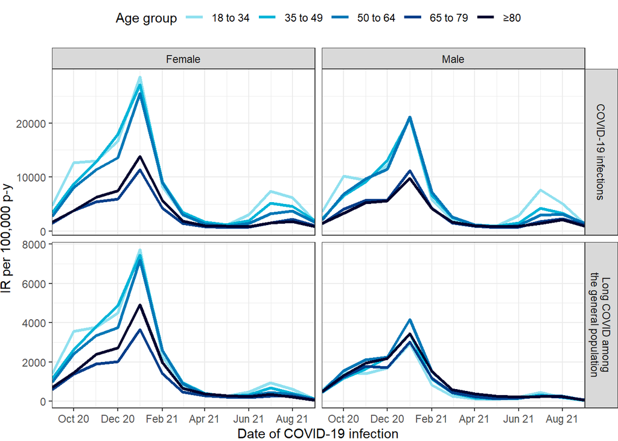

##### B. CPRD

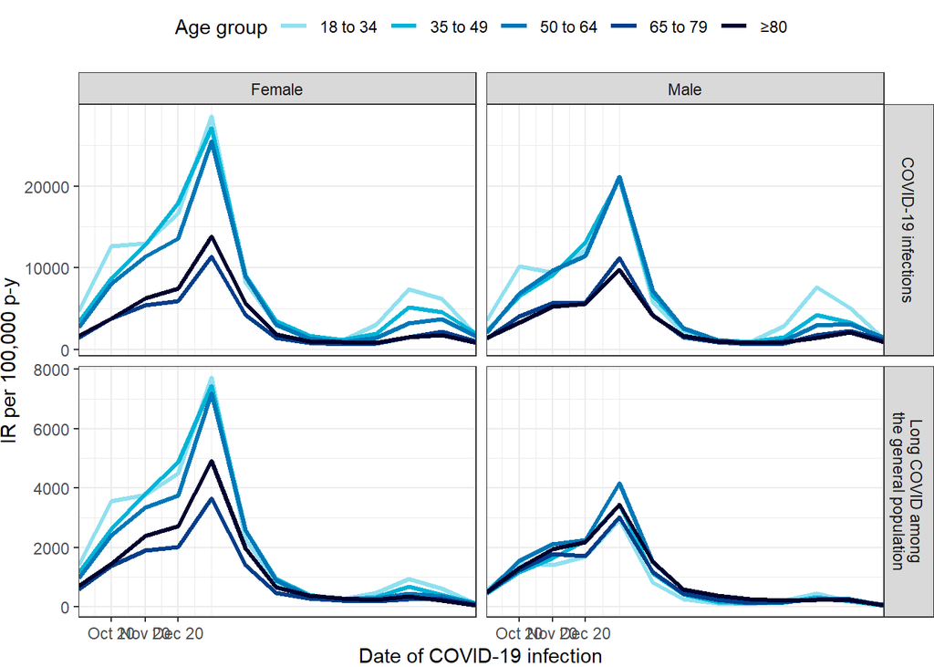

### Relative Risks - infections vs first negative test

#### 1. Table: RR of long COVID symptoms: COVID-19 infection vs first SARS-CoV-2 negative test - 90 days

| Database | Symptom | Events COVID-19 infection | Events first negative test | Relative risk [with 95%CI] |
| --- | --- | --- | --- | --- |
| SIDIAP | Altered smell taste | 525 | 550 | 2.58 [2.29;2.91] |
| SIDIAP | Fatigue malaise | 6389 | 16294 | 1.06 [1.03;1.09] |
| SIDIAP | Menstrual problems | 2480 | 6842 | 0.98 [0.94;1.03] |
| SIDIAP | Cognitive dysfunction brain fog | 234 | 656 | 0.96 [0.83;1.12] |
| SIDIAP | Joint pain | 10187 | 29214 | 0.94 [0.92;0.96] |
| SIDIAP | Allergy | 3977 | 11401 | 0.94 [0.91;0.98] |
| SIDIAP | Memory issues | 389 | 1115 | 0.94 [0.84;1.06] |
| SIDIAP | Tinnitus hearing problems | 2485 | 7205 | 0.93 [0.89;0.98] |
| SIDIAP | Tachycardia | 3221 | 9411 | 0.92 [0.89;0.96] |
| SIDIAP | Neuralgia | 1916 | 5599 | 0.92 [0.88;0.97] |
| SIDIAP | Headache | 7140 | 21156 | 0.91 [0.89;0.94] |
| SIDIAP | Abdominal pain | 10238 | 30564 | 0.91 [0.89;0.93] |
| SIDIAP | Chest pain or angina | 4867 | 14527 | 0.91 [0.88;0.93] |
| SIDIAP | Blurred vision | 419 | 1239 | 0.91 [0.82;1.02] |
| SIDIAP | Dizziness | 3108 | 9285 | 0.90 [0.87;0.94] |
| SIDIAP | Pins and needles sensation | 749 | 2252 | 0.90 [0.83;0.98] |
| SIDIAP | Dyspnea | 5952 | 18180 | 0.88 [0.86;0.91] |
| SIDIAP | Intermittent fever | 321 | 983 | 0.88 [0.78;1.00] |
| SIDIAP | Gastrointestinal issues | 9119 | 28450 | 0.87 [0.85;0.89] |
| SIDIAP | Cough | 10868 | 34085 | 0.86 [0.84;0.88] |
| SIDIAP | Sleep disorder | 2875 | 9108 | 0.85 [0.82;0.89] |
| SIDIAP | Anxiety | 11070 | 35812 | 0.84 [0.82;0.85] |
| SIDIAP | Muscle spasms and pain | 198 | 654 | 0.82 [0.70;0.96] |
| SIDIAP | Depression wo recurrence | 10755 | 35931 | 0.81 [0.79;0.83] |
| CPRD AURUM | Altered smell taste | 525 | 550 | 2.58 [2.29;2.91] |
| CPRD AURUM | Fatigue malaise | 6389 | 16294 | 1.06 [1.03;1.09] |
| CPRD AURUM | Menstrual problems | 2480 | 6842 | 0.98 [0.94;1.03] |
| CPRD AURUM | Cognitive dysfunction brain fog | 234 | 656 | 0.96 [0.83;1.12] |
| CPRD AURUM | Joint pain | 10187 | 29214 | 0.94 [0.92;0.96] |
| CPRD AURUM | Allergy | 3977 | 11401 | 0.94 [0.91;0.98] |
| CPRD AURUM | Memory issues | 389 | 1115 | 0.94 [0.84;1.06] |
| CPRD AURUM | Tinnitus hearing problems | 2485 | 7205 | 0.93 [0.89;0.98] |
| CPRD AURUM | Tachycardia | 3221 | 9411 | 0.92 [0.89;0.96] |
| CPRD AURUM | Neuralgia | 1916 | 5599 | 0.92 [0.88;0.97] |
| CPRD AURUM | Headache | 7140 | 21156 | 0.91 [0.89;0.94] |
| CPRD AURUM | Abdominal pain | 10238 | 30564 | 0.91 [0.89;0.93] |
| CPRD AURUM | Chest pain or angina | 4867 | 14527 | 0.91 [0.88;0.93] |
| CPRD AURUM | Blurred vision | 419 | 1239 | 0.91 [0.82;1.02] |
| CPRD AURUM | Dizziness | 3108 | 9285 | 0.90 [0.87;0.94] |
| CPRD AURUM | Pins and needles sensation | 749 | 2252 | 0.90 [0.83;0.98] |
| CPRD AURUM | Dyspnea | 5952 | 18180 | 0.88 [0.86;0.91] |
| CPRD AURUM | Intermittent fever | 321 | 983 | 0.88 [0.78;1.00] |
| CPRD AURUM | Gastrointestinal issues | 9119 | 28450 | 0.87 [0.85;0.89] |
| CPRD AURUM | Cough | 10868 | 34085 | 0.86 [0.84;0.88] |
| CPRD AURUM | Sleep disorder | 2875 | 9108 | 0.85 [0.82;0.89] |
| CPRD AURUM | Anxiety | 11070 | 35812 | 0.84 [0.82;0.85] |
| CPRD AURUM | Muscle spasms and pain | 198 | 654 | 0.82 [0.70;0.96] |
| CPRD AURUM | Depression wo recurrence | 10755 | 35931 | 0.81 [0.79;0.83] |

#### 2. Table: RR of long COVID symptoms: COVID-19 infection vs first SARS-CoV-2 negative test - 28 days

| Database | Symptom | Events COVID-19 infection | Events first negative test | Relative risk [with 95%CI] |
| --- | --- | --- | --- | --- |
| SIDIAP | Altered smell taste | 660 | 686 | 2.60 [2.34;2.89] |
| SIDIAP | Fatigue malaise | 7875 | 19638 | 1.08 [1.06;1.11] |
| SIDIAP | Menstrual problems | 3069 | 8353 | 0.99 [0.95;1.03] |
| SIDIAP | Memory issues | 460 | 1289 | 0.96 [0.87;1.07] |
| SIDIAP | Cognitive dysfunction brain fog | 275 | 775 | 0.96 [0.84;1.10] |
| SIDIAP | Tachycardia | 3965 | 11299 | 0.95 [0.91;0.98] |
| SIDIAP | Joint pain | 11962 | 34289 | 0.94 [0.92;0.96] |
| SIDIAP | Chest pain or angina | 6178 | 17837 | 0.94 [0.91;0.96] |
| SIDIAP | Dyspnea | 7552 | 21786 | 0.94 [0.91;0.96] |
| SIDIAP | Allergy | 4617 | 13375 | 0.93 [0.90;0.96] |
| SIDIAP | Tinnitus hearing problems | 2997 | 8690 | 0.93 [0.89;0.97] |
| SIDIAP | Neuralgia | 2266 | 6598 | 0.93 [0.88;0.97] |
| SIDIAP | Pins and needles sensation | 942 | 2740 | 0.93 [0.86;1.00] |
| SIDIAP | Headache | 8654 | 25650 | 0.91 [0.89;0.93] |
| SIDIAP | Abdominal pain | 12420 | 37058 | 0.91 [0.89;0.92] |
| SIDIAP | Dizziness | 3758 | 11279 | 0.90 [0.87;0.93] |
| SIDIAP | Blurred vision | 524 | 1593 | 0.89 [0.81;0.98] |
| SIDIAP | Intermittent fever | 395 | 1198 | 0.89 [0.80;1.00] |
| SIDIAP | Gastrointestinal issues | 11071 | 34138 | 0.88 [0.86;0.89] |
| SIDIAP | Cough | 12474 | 39296 | 0.86 [0.84;0.87] |
| SIDIAP | Sleep disorder | 3642 | 11552 | 0.85 [0.82;0.88] |
| SIDIAP | Anxiety | 13027 | 42070 | 0.84 [0.82;0.85] |
| SIDIAP | Muscle spasms and pain | 241 | 786 | 0.83 [0.72;0.96] |
| SIDIAP | Depression wo recurrence | 12456 | 42078 | 0.80 [0.78;0.82] |
| CPRD AURUM | Altered smell taste | 660 | 686 | 2.60 [2.34;2.89] |
| CPRD AURUM | Fatigue malaise | 7875 | 19638 | 1.08 [1.06;1.11] |
| CPRD AURUM | Menstrual problems | 3069 | 8353 | 0.99 [0.95;1.03] |
| CPRD AURUM | Memory issues | 460 | 1289 | 0.96 [0.87;1.07] |
| CPRD AURUM | Cognitive dysfunction brain fog | 275 | 775 | 0.96 [0.84;1.10] |
| CPRD AURUM | Tachycardia | 3965 | 11299 | 0.95 [0.91;0.98] |
| CPRD AURUM | Joint pain | 11962 | 34289 | 0.94 [0.92;0.96] |
| CPRD AURUM | Chest pain or angina | 6178 | 17837 | 0.94 [0.91;0.96] |
| CPRD AURUM | Dyspnea | 7552 | 21786 | 0.94 [0.91;0.96] |
| CPRD AURUM | Allergy | 4617 | 13375 | 0.93 [0.90;0.96] |
| CPRD AURUM | Tinnitus hearing problems | 2997 | 8690 | 0.93 [0.89;0.97] |
| CPRD AURUM | Neuralgia | 2266 | 6598 | 0.93 [0.88;0.97] |
| CPRD AURUM | Pins and needles sensation | 942 | 2740 | 0.93 [0.86;1.00] |
| CPRD AURUM | Headache | 8654 | 25650 | 0.91 [0.89;0.93] |
| CPRD AURUM | Abdominal pain | 12420 | 37058 | 0.91 [0.89;0.92] |
| CPRD AURUM | Dizziness | 3758 | 11279 | 0.90 [0.87;0.93] |
| CPRD AURUM | Blurred vision | 524 | 1593 | 0.89 [0.81;0.98] |
| CPRD AURUM | Intermittent fever | 395 | 1198 | 0.89 [0.80;1.00] |
| CPRD AURUM | Gastrointestinal issues | 11071 | 34138 | 0.88 [0.86;0.89] |
| CPRD AURUM | Cough | 12474 | 39296 | 0.86 [0.84;0.87] |
| CPRD AURUM | Sleep disorder | 3642 | 11552 | 0.85 [0.82;0.88] |
| CPRD AURUM | Anxiety | 13027 | 42070 | 0.84 [0.82;0.85] |
| CPRD AURUM | Muscle spasms and pain | 241 | 786 | 0.83 [0.72;0.96] |
| CPRD AURUM | Depression wo recurrence | 12456 | 42078 | 0.80 [0.78;0.82] |

#### 3. Figure: RR of long COVID symptoms: COVID-19 infection vs first SARS-CoV-2 negative test - 28 days

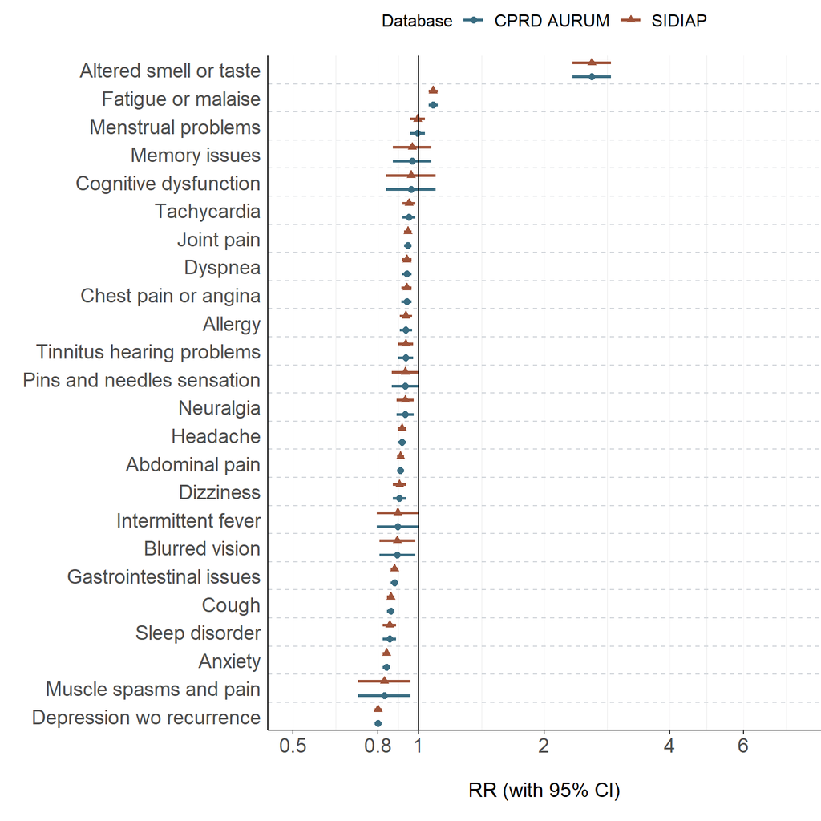

### Relative Risks - re-infections vs first infection

#### 1. Table: RR of long-COVID symptoms, first infection vs re-infection - 90 days

| Database | Symptom | Events re-infection | Events first infection | Relative risk [with 95%CI] |
| --- | --- | --- | --- | --- |
| SIDIAP | Menstrual problems | 692 | 1315 | 1.08 [0.99;1.18] |
| SIDIAP | Muscle spasms and pain | 86 | 159 | 1.11 [0.85;1.44] |
| SIDIAP | Anxiety | 3734 | 6644 | 1.15 [1.11;1.20] |
| SIDIAP | Depression wo recurrence | 3881 | 6783 | 1.17 [1.13;1.22] |
| SIDIAP | Blurred vision | 188 | 318 | 1.21 [1.01;1.45] |
| SIDIAP | Dyspnea | 3113 | 5211 | 1.23 [1.17;1.28] |
| SIDIAP | Headache | 2528 | 4161 | 1.25 [1.19;1.31] |
| SIDIAP | Neuralgia | 737 | 1197 | 1.26 [1.15;1.39] |
| SIDIAP | Sleep disorder | 1263 | 2046 | 1.27 [1.18;1.36] |
| SIDIAP | Cough | 4714 | 7589 | 1.28 [1.23;1.32] |
| SIDIAP | Abdominal pain | 3804 | 6081 | 1.28 [1.23;1.34] |
| SIDIAP | Memory issues | 234 | 373 | 1.29 [1.09;1.52] |
| SIDIAP | Tinnitus hearing problems | 1095 | 1741 | 1.29 [1.20;1.39] |
| SIDIAP | Gastrointestinal issues | 3901 | 6211 | 1.29 [1.24;1.34] |
| SIDIAP | Chest pain or angina | 2048 | 3211 | 1.31 [1.24;1.38] |
| SIDIAP | Dizziness | 1313 | 2046 | 1.32 [1.23;1.41] |
| SIDIAP | Tachycardia | 1521 | 2354 | 1.33 [1.24;1.41] |
| SIDIAP | Allergy | 1403 | 2164 | 1.33 [1.25;1.42] |
| SIDIAP | Joint pain | 4031 | 6196 | 1.34 [1.28;1.39] |
| SIDIAP | Fatigue malaise | 2628 | 3839 | 1.41 [1.34;1.48] |
| SIDIAP | Cognitive dysfunction brain fog | 141 | 195 | 1.48 [1.20;1.84] |
| SIDIAP | Altered smell taste | 171 | 238 | 1.48 [1.21;1.80] |
| SIDIAP | Pins and needles sensation | 297 | 410 | 1.49 [1.28;1.73] |
| SIDIAP | Intermittent fever | 187 | 248 | 1.55 [1.28;1.87] |
| CPRD AURUM | Menstrual problems | 692 | 1315 | 1.08 [0.99;1.18] |
| CPRD AURUM | Muscle spasms and pain | 86 | 159 | 1.11 [0.85;1.44] |
| CPRD AURUM | Anxiety | 3734 | 6644 | 1.15 [1.11;1.20] |
| CPRD AURUM | Depression wo recurrence | 3881 | 6783 | 1.17 [1.13;1.22] |
| CPRD AURUM | Blurred vision | 188 | 318 | 1.21 [1.01;1.45] |
| CPRD AURUM | Dyspnea | 3113 | 5211 | 1.23 [1.17;1.28] |
| CPRD AURUM | Headache | 2528 | 4161 | 1.25 [1.19;1.31] |
| CPRD AURUM | Neuralgia | 737 | 1197 | 1.26 [1.15;1.39] |
| CPRD AURUM | Sleep disorder | 1263 | 2046 | 1.27 [1.18;1.36] |
| CPRD AURUM | Cough | 4714 | 7589 | 1.28 [1.23;1.32] |
| CPRD AURUM | Abdominal pain | 3804 | 6081 | 1.28 [1.23;1.34] |
| CPRD AURUM | Memory issues | 234 | 373 | 1.29 [1.09;1.52] |
| CPRD AURUM | Tinnitus hearing problems | 1095 | 1741 | 1.29 [1.20;1.39] |
| CPRD AURUM | Gastrointestinal issues | 3901 | 6211 | 1.29 [1.24;1.34] |
| CPRD AURUM | Chest pain or angina | 2048 | 3211 | 1.31 [1.24;1.38] |
| CPRD AURUM | Dizziness | 1313 | 2046 | 1.32 [1.23;1.41] |
| CPRD AURUM | Tachycardia | 1521 | 2354 | 1.33 [1.24;1.41] |
| CPRD AURUM | Allergy | 1403 | 2164 | 1.33 [1.25;1.42] |
| CPRD AURUM | Joint pain | 4031 | 6196 | 1.34 [1.28;1.39] |
| CPRD AURUM | Fatigue malaise | 2628 | 3839 | 1.41 [1.34;1.48] |
| CPRD AURUM | Cognitive dysfunction brain fog | 141 | 195 | 1.48 [1.20;1.84] |
| CPRD AURUM | Altered smell taste | 171 | 238 | 1.48 [1.21;1.80] |
| CPRD AURUM | Pins and needles sensation | 297 | 410 | 1.49 [1.28;1.73] |
| CPRD AURUM | Intermittent fever | 187 | 248 | 1.55 [1.28;1.87] |

#### 2. Table: RR of long-COVID symptoms, first infection vs re-infection - 28 days

| Database | Symptom | Events re-infection | Events first infection | Relative risk [with 95%CI] |
| --- | --- | --- | --- | --- |
| SIDIAP | Muscle spasms and pain | 103 | 209 | 1.01 [0.80;1.28] |
| SIDIAP | Menstrual problems | 897 | 1664 | 1.11 [1.02;1.20] |
| SIDIAP | Anxiety | 4611 | 8112 | 1.17 [1.13;1.21] |
| SIDIAP | Depression wo recurrence | 4592 | 7967 | 1.18 [1.14;1.23] |
| SIDIAP | Blurred vision | 234 | 405 | 1.19 [1.01;1.39] |
| SIDIAP | Neuralgia | 869 | 1501 | 1.19 [1.09;1.29] |
| SIDIAP | Cough | 5698 | 9524 | 1.23 [1.19;1.27] |
| SIDIAP | Dyspnea | 4206 | 6932 | 1.25 [1.20;1.29] |
| SIDIAP | Abdominal pain | 4685 | 7675 | 1.25 [1.21;1.30] |
| SIDIAP | Headache | 3214 | 5249 | 1.26 [1.20;1.31] |
| SIDIAP | Sleep disorder | 1652 | 2681 | 1.27 [1.19;1.34] |
| SIDIAP | Gastrointestinal issues | 4975 | 8019 | 1.27 [1.23;1.32] |
| SIDIAP | Allergy | 1704 | 2730 | 1.28 [1.21;1.36] |
| SIDIAP | Memory issues | 300 | 478 | 1.29 [1.12;1.49] |
| SIDIAP | Joint pain | 4859 | 7696 | 1.30 [1.25;1.34] |
| SIDIAP | Tachycardia | 2000 | 3105 | 1.32 [1.25;1.40] |
| SIDIAP | Tinnitus hearing problems | 1371 | 2112 | 1.33 [1.25;1.43] |
| SIDIAP | Dizziness | 1671 | 2566 | 1.34 [1.26;1.42] |
| SIDIAP | Chest pain or angina | 2725 | 4191 | 1.34 [1.27;1.40] |
| SIDIAP | Pins and needles sensation | 384 | 573 | 1.38 [1.21;1.57] |
| SIDIAP | Fatigue malaise | 3397 | 5016 | 1.39 [1.33;1.45] |
| SIDIAP | Cognitive dysfunction brain fog | 188 | 262 | 1.47 [1.22;1.78] |
| SIDIAP | Intermittent fever | 239 | 320 | 1.53 [1.30;1.81] |
| SIDIAP | Altered smell taste | 247 | 320 | 1.59 [1.34;1.87] |
| CPRD AURUM | Muscle spasms and pain | 103 | 209 | 1.01 [0.80;1.28] |
| CPRD AURUM | Menstrual problems | 897 | 1664 | 1.11 [1.02;1.20] |
| CPRD AURUM | Anxiety | 4611 | 8112 | 1.17 [1.13;1.21] |
| CPRD AURUM | Depression wo recurrence | 4592 | 7967 | 1.18 [1.14;1.23] |
| CPRD AURUM | Blurred vision | 234 | 405 | 1.19 [1.01;1.39] |
| CPRD AURUM | Neuralgia | 869 | 1501 | 1.19 [1.09;1.29] |
| CPRD AURUM | Cough | 5698 | 9524 | 1.23 [1.19;1.27] |
| CPRD AURUM | Dyspnea | 4206 | 6932 | 1.25 [1.20;1.29] |
| CPRD AURUM | Abdominal pain | 4685 | 7675 | 1.25 [1.21;1.30] |
| CPRD AURUM | Headache | 3214 | 5249 | 1.26 [1.20;1.31] |
| CPRD AURUM | Sleep disorder | 1652 | 2681 | 1.27 [1.19;1.34] |
| CPRD AURUM | Gastrointestinal issues | 4975 | 8019 | 1.27 [1.23;1.32] |
| CPRD AURUM | Allergy | 1704 | 2730 | 1.28 [1.21;1.36] |
| CPRD AURUM | Memory issues | 300 | 478 | 1.29 [1.12;1.49] |
| CPRD AURUM | Joint pain | 4859 | 7696 | 1.30 [1.25;1.34] |
| CPRD AURUM | Tachycardia | 2000 | 3105 | 1.32 [1.25;1.40] |
| CPRD AURUM | Tinnitus hearing problems | 1371 | 2112 | 1.33 [1.25;1.43] |
| CPRD AURUM | Dizziness | 1671 | 2566 | 1.34 [1.26;1.42] |
| CPRD AURUM | Chest pain or angina | 2725 | 4191 | 1.34 [1.27;1.40] |
| CPRD AURUM | Pins and needles sensation | 384 | 573 | 1.38 [1.21;1.57] |
| CPRD AURUM | Fatigue malaise | 3397 | 5016 | 1.39 [1.33;1.45] |
| CPRD AURUM | Cognitive dysfunction brain fog | 188 | 262 | 1.47 [1.22;1.78] |
| CPRD AURUM | Intermittent fever | 239 | 320 | 1.53 [1.30;1.81] |
| CPRD AURUM | Altered smell taste | 247 | 320 | 1.59 [1.34;1.87] |

#### 3. Figure: RR of long-COVID symptoms, first infection vs re-infection - 28 days

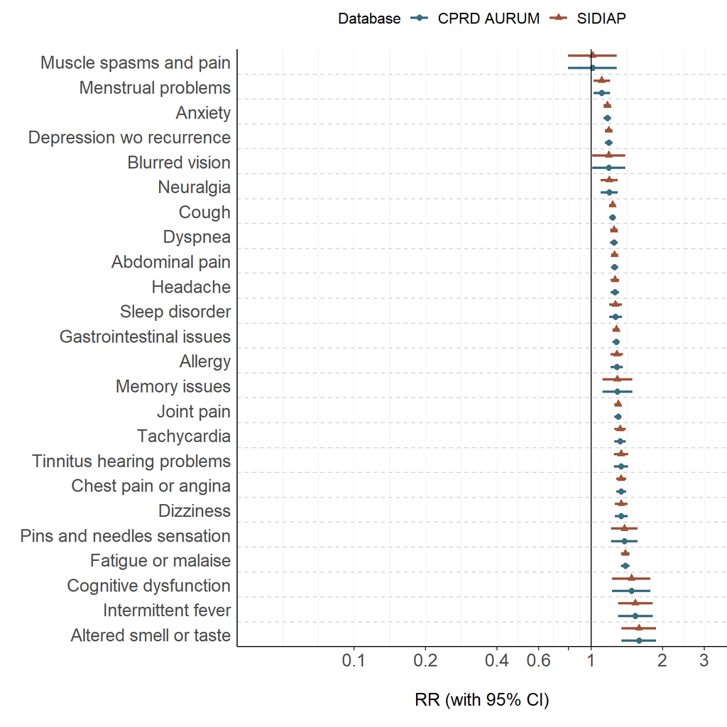

### Relative Risks - infections vs all negative tests

#### 1. Table: RR of long COVID symptoms, COVID-19 infection vs all SARS-CoV-2 negative tests - 90 days

[output not shown]

#### 2. Figure: RR of long COVID symptoms, COVID-19 infection vs SARS-CoV-2 negative tests (all records) - 90 days

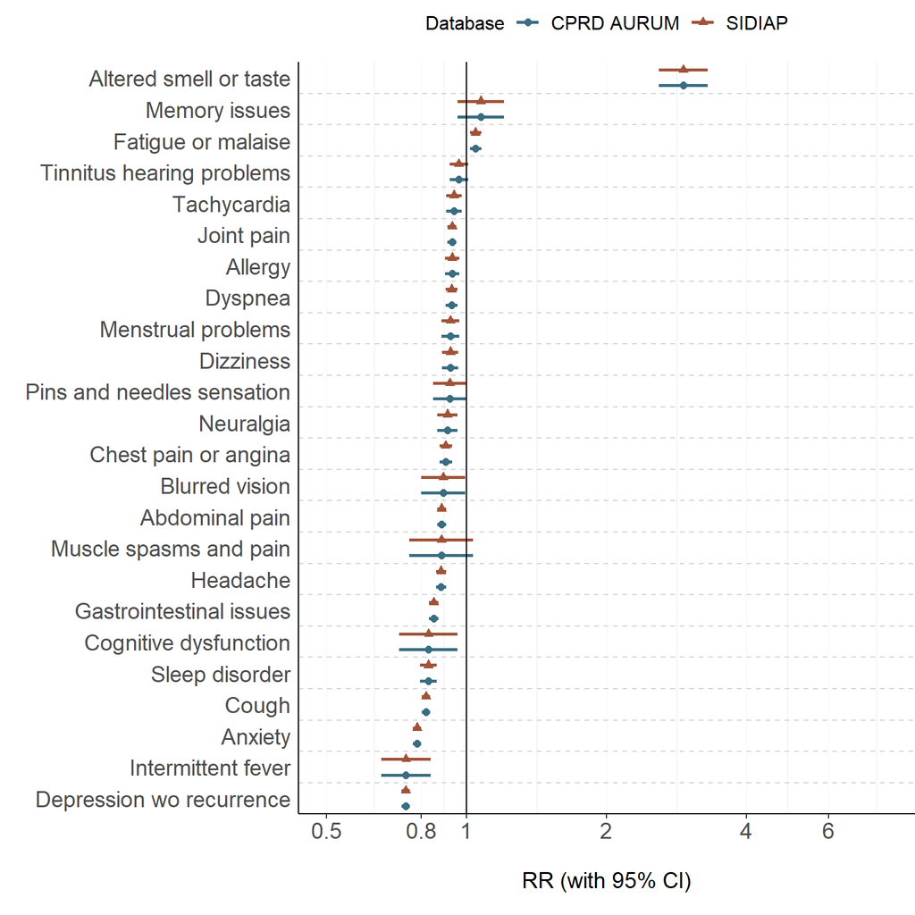

#### 3. Table: RR of long COVID symptoms, COVID-19 infection vs all SARS-CoV-2 negative tests - 28 days

[output not shown]

#### 4. Figure: RR of long COVID symptoms, COVID-19 infection vs SARS-CoV-2 negative tests (all records) - 28 days

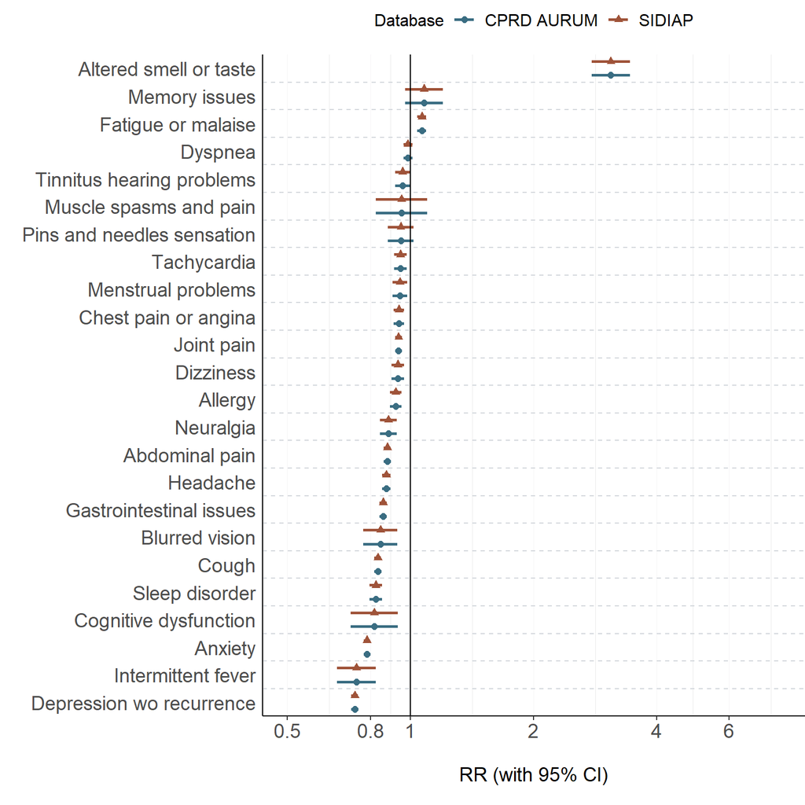